# ANCOVA in Vocabulario (Vocabulario)

Geiser C. Challco geiser@alumni.usp.br

- Descriptive Statistics of Initial Data
- ANCOVA and Pairwise for one factor: **grupo**
  - Without remove non-normal data
  - Computing ANCOVA and PairWise After removing non-normal data (OK)
    - Plots for ancova
    - Checking linearity assumption
    - Checking normality and homogeneity
- ANCOVA and Pairwise for two factors **grupo:Sexo**
  - Without remove non-normal data
  - Computing ANCOVA and PairWise After removing non-normal data (OK)
    - Plots for ancova
    - Checking linearity assumption
    - Checking normality and homogeneity
- ANCOVA and Pairwise for two factors **grupo:Zona**
  - Without remove non-normal data
  - Computing ANCOVA and PairWise After removing non-normal data (OK)
    - Plots for ancova
    - Checking linearity assumption
    - Checking normality and homogeneity
- ANCOVA and Pairwise for two factors **grupo:Cor.Raca**
  - Without remove non-normal data
  - Computing ANCOVA and PairWise After removing non-normal data (OK)
    - Plots for ancova
    - Checking linearity assumption
    - Checking normality and homogeneity
- ANCOVA and Pairwise for two factors **grupo:vocab.quintile**
  - Without remove non-normal data
  - Computing ANCOVA and PairWise After removing non-normal data (OK)
    - Plots for ancova
    - Checking linearity assumption
    - Checking normality and homogeneity
- Summary of Results
  - Descriptive Statistics
  - ANCOVA Table Comparison
  - PairWise Table Comparison
  - EMMS Table Comparison

**NOTE**:

- Teste ANCOVA para determinar se houve diferenças significativas no Vocabulario (medido usando pre- e pos-testes).
- ANCOVA test to determine whether there were significant differences in Vocabulario (measured using pre- and post-tests).

# Descriptive Statistics of Initial Data

```r
df <- get.descriptives(dat, c(dv.pre, dv.pos), c("grupo"),
                       include.global = T, symmetry.test = T, normality.test = F)
df <- plyr::rbind.fill(
  df, do.call(plyr::rbind.fill, lapply(lfatores2, FUN = function(f) {
    if (nrow(dat) > 0 && sum(!is.na(unique(dat[[f]]))) > 1)
      get.descriptives(dat, c(dv.pre,dv.pos), c("grupo", f),
                       symmetry.test = T, normality.test = F)
    }))
)
(df <- df[,c(fatores1[fatores1 %in% colnames(df)],"variable",
             colnames(df)[!colnames(df) %in% c(fatores1,"variable")])])
```

```
##           grupo Sexo   Zona Cor.Raca vocab.quintile  variable   n   mean median min max     sd    se     ci
## 1      Controle <NA>   <NA>     <NA>           <NA> vocab.pre 100 27.090   27.0   6  45  8.625 0.862  1.711
## 2  Experimental <NA>   <NA>     <NA>           <NA> vocab.pre 181 28.221   29.0   6  43  8.540 0.635  1.253
## 3          <NA> <NA>   <NA>     <NA>           <NA> vocab.pre 281 27.819   28.0   6  45  8.572 0.511  1.007
## 4      Controle <NA>   <NA>     <NA>           <NA> vocab.pos 100 27.350   29.0   0  45 10.700 1.070  2.123
## 5  Experimental <NA>   <NA>     <NA>           <NA> vocab.pos 181 29.044   30.0   7  44  9.018 0.670  1.323
## 6          <NA> <NA>   <NA>     <NA>           <NA> vocab.pos 281 28.441   30.0   0  45  9.665 0.577  1.135
## 7      Controle    F   <NA>     <NA>           <NA> vocab.pre  53 27.868   28.0   6  45  8.700 1.195  2.398
## 8      Controle    M   <NA>     <NA>           <NA> vocab.pre  47 26.213   25.0  12  42  8.546 1.247  2.509
## 9  Experimental    F   <NA>     <NA>           <NA> vocab.pre  96 29.229   30.5   6  43  8.921 0.911  1.808
## 10 Experimental    M   <NA>     <NA>           <NA> vocab.pre  85 27.082   28.0   8  43  7.987 0.866  1.723
## 11     Controle    F   <NA>     <NA>           <NA> vocab.pos  53 28.660   31.0   0  45 10.681 1.467  2.944
## 12     Controle    M   <NA>     <NA>           <NA> vocab.pos  47 25.872   28.0   3  44 10.642 1.552  3.124
## 13 Experimental    F   <NA>     <NA>           <NA> vocab.pos  96 30.438   32.0   8  44  9.028 0.921  1.829
## 14 Experimental    M   <NA>     <NA>           <NA> vocab.pos  85 27.471   29.0   7  43  8.795 0.954  1.897
```

[output cut: 98 more lines]

| grupo | Sexo | Zona | Cor.Raca | vocab.quintile | variable | n | mean | median | min | max | sd | se | ci | iqr | symmetry | skewness | kurtosis |
| --- | --- | --- | --- | --- | --- | --- | --- | --- | --- | --- | --- | --- | --- | --- | --- | --- | --- |
| Controle |  |  |  |  | vocab.pre | 100 | 27.090 | 27.0 | 6 | 45 | 8.625 | 0.862 | 1.711 | 12.25 | YES | -0.258 | -0.513 |
| Experimental |  |  |  |  | vocab.pre | 181 | 28.221 | 29.0 | 6 | 43 | 8.540 | 0.635 | 1.253 | 13.00 | YES | -0.453 | -0.499 |
|  |  |  |  |  | vocab.pre | 281 | 27.819 | 28.0 | 6 | 45 | 8.572 | 0.511 | 1.007 | 13.00 | YES | -0.384 | -0.505 |
| Controle |  |  |  |  | vocab.pos | 100 | 27.350 | 29.0 | 0 | 45 | 10.700 | 1.070 | 2.123 | 15.50 | NO | -0.548 | -0.650 |
| Experimental |  |  |  |  | vocab.pos | 181 | 29.044 | 30.0 | 7 | 44 | 9.018 | 0.670 | 1.323 | 13.00 | YES | -0.400 | -0.719 |
|  |  |  |  |  | vocab.pos | 281 | 28.441 | 30.0 | 0 | 45 | 9.665 | 0.577 | 1.135 | 14.00 | NO | -0.516 | -0.517 |
| Controle | F |  |  |  | vocab.pre | 53 | 27.868 | 28.0 | 6 | 45 | 8.700 | 1.195 | 2.398 | 9.00 | NO | -0.548 | 0.217 |
| Controle | M |  |  |  | vocab.pre | 47 | 26.213 | 25.0 | 12 | 42 | 8.546 | 1.247 | 2.509 | 15.00 | YES | 0.076 | -1.259 |
| Experimental | F |  |  |  | vocab.pre | 96 | 29.229 | 30.5 | 6 | 43 | 8.921 | 0.911 | 1.808 | 13.00 | NO | -0.556 | -0.543 |
| Experimental | M |  |  |  | vocab.pre | 85 | 27.082 | 28.0 | 8 | 43 | 7.987 | 0.866 | 1.723 | 11.00 | YES | -0.409 | -0.405 |
| Controle | F |  |  |  | vocab.pos | 53 | 28.660 | 31.0 | 0 | 45 | 10.681 | 1.467 | 2.944 | 10.00 | NO | -0.819 | -0.130 |
| Controle | M |  |  |  | vocab.pos | 47 | 25.872 | 28.0 | 3 | 44 | 10.642 | 1.552 | 3.124 | 18.00 | YES | -0.254 | -1.069 |
| Experimental | F |  |  |  | vocab.pos | 96 | 30.438 | 32.0 | 8 | 44 | 9.028 | 0.921 | 1.829 | 14.00 | NO | -0.525 | -0.624 |
| Experimental | M |  |  |  | vocab.pos | 85 | 27.471 | 29.0 | 7 | 43 | 8.795 | 0.954 | 1.897 | 13.00 | YES | -0.304 | -0.792 |
| Controle |  | Rural |  |  | vocab.pre | 38 | 26.711 | 27.0 | 7 | 45 | 8.427 | 1.367 | 2.770 | 10.75 | YES | -0.232 | -0.460 |
| Controle |  | Urbana |  |  | vocab.pre | 18 | 26.944 | 26.5 | 12 | 41 | 7.635 | 1.800 | 3.797 | 8.50 | YES | -0.177 | -0.703 |
| Controle |  |  |  |  | vocab.pre | 44 | 27.477 | 27.0 | 6 | 43 | 9.317 | 1.405 | 2.833 | 15.50 | YES | -0.303 | -0.736 |
| Experimental |  | Rural |  |  | vocab.pre | 56 | 27.804 | 28.5 | 8 | 41 | 8.490 | 1.135 | 2.274 | 13.00 | NO | -0.566 | -0.454 |
| Experimental |  | Urbana |  |  | vocab.pre | 33 | 29.061 | 30.0 | 12 | 39 | 7.976 | 1.388 | 2.828 | 12.00 | NO | -0.688 | -0.576 |
| Experimental |  |  |  |  | vocab.pre | 92 | 28.174 | 29.0 | 6 | 43 | 8.829 | 0.920 | 1.828 | 13.00 | YES | -0.305 | -0.616 |
| Controle |  | Rural |  |  | vocab.pos | 38 | 27.868 | 31.0 | 3 | 42 | 10.333 | 1.676 | 3.396 | 9.50 | NO | -0.943 | -0.157 |
| Controle |  | Urbana |  |  | vocab.pos | 18 | 31.222 | 30.5 | 14 | 45 | 8.063 | 1.900 | 4.009 | 10.00 | YES | -0.211 | -0.536 |
| Controle |  |  |  |  | vocab.pos | 44 | 25.318 | 27.0 | 0 | 44 | 11.631 | 1.754 | 3.536 | 18.50 | YES | -0.141 | -1.212 |
| Experimental |  | Rural |  |  | vocab.pos | 56 | 28.446 | 29.0 | 8 | 44 | 9.045 | 1.209 | 2.422 | 13.25 | YES | -0.254 | -0.865 |
| Experimental |  | Urbana |  |  | vocab.pos | 33 | 31.030 | 32.0 | 12 | 43 | 8.687 | 1.512 | 3.080 | 13.00 | NO | -0.541 | -0.816 |
| Experimental |  |  |  |  | vocab.pos | 92 | 28.696 | 30.0 | 7 | 44 | 9.116 | 0.950 | 1.888 | 12.75 | YES | -0.423 | -0.681 |
| Controle |  |  | Branca |  | vocab.pre | 3 | 35.667 | 36.0 | 29 | 42 | 6.506 | 3.756 | 16.163 | 6.50 | few data | 0.000 | 0.000 |
| Controle |  |  | Indígena |  | vocab.pre | 1 | 34.000 | 34.0 | 34 | 34 |  |  |  | 0.00 | few data | 0.000 | 0.000 |
| Controle |  |  | Parda |  | vocab.pre | 38 | 27.316 | 27.5 | 7 | 45 | 8.269 | 1.341 | 2.718 | 10.00 | YES | -0.319 | -0.170 |
| Controle |  |  |  |  | vocab.pre | 58 | 26.379 | 26.5 | 6 | 43 | 8.835 | 1.160 | 2.323 | 14.75 | YES | -0.157 | -0.768 |
| Experimental |  |  | Amarela |  | vocab.pre | 1 | 23.000 | 23.0 | 23 | 23 |  |  |  | 0.00 | few data | 0.000 | 0.000 |
| Experimental |  |  | Branca |  | vocab.pre | 19 | 30.000 | 29.0 | 19 | 40 | 6.333 | 1.453 | 3.053 | 9.00 | YES | 0.160 | -1.168 |
| Experimental |  |  | Parda |  | vocab.pre | 53 | 26.925 | 28.0 | 8 | 43 | 9.713 | 1.334 | 2.677 | 13.00 | YES | -0.458 | -0.888 |
| Experimental |  |  |  |  | vocab.pre | 108 | 28.593 | 29.5 | 6 | 43 | 8.264 | 0.795 | 1.576 | 13.00 | YES | -0.367 | -0.624 |
| Controle |  |  | Branca |  | vocab.pos | 3 | 37.000 | 40.0 | 29 | 42 | 7.000 | 4.041 | 17.389 | 6.50 | few data | 0.000 | 0.000 |
| Controle |  |  | Indígena |  | vocab.pos | 1 | 38.000 | 38.0 | 38 | 38 |  |  |  | 0.00 | few data | 0.000 | 0.000 |
| Controle |  |  | Parda |  | vocab.pos | 38 | 26.921 | 31.0 | 0 | 42 | 11.581 | 1.879 | 3.807 | 16.25 | NO | -0.806 | -0.586 |
| Controle |  |  |  |  | vocab.pos | 58 | 26.948 | 29.0 | 9 | 45 | 10.144 | 1.332 | 2.667 | 14.50 | YES | -0.205 | -0.993 |
| Experimental |  |  | Amarela |  | vocab.pos | 1 | 26.000 | 26.0 | 26 | 26 |  |  |  | 0.00 | few data | 0.000 | 0.000 |
| Experimental |  |  | Branca |  | vocab.pos | 19 | 29.474 | 29.0 | 14 | 43 | 8.784 | 2.015 | 4.234 | 12.50 | YES | -0.308 | -1.177 |
| Experimental |  |  | Parda |  | vocab.pos | 53 | 28.962 | 31.0 | 8 | 44 | 9.567 | 1.314 | 2.637 | 16.00 | YES | -0.392 | -0.827 |
| Experimental |  |  |  |  | vocab.pos | 108 | 29.037 | 30.5 | 7 | 44 | 8.900 | 0.856 | 1.698 | 12.50 | YES | -0.411 | -0.702 |
| Controle |  |  |  | 1st quintile | vocab.pre | 13 | 12.308 | 13.0 | 6 | 16 | 3.276 | 0.909 | 1.980 | 4.00 | NO | -0.633 | -1.001 |
| Controle |  |  |  | 2nd quintile | vocab.pre | 14 | 19.286 | 19.0 | 17 | 22 | 1.541 | 0.412 | 0.890 | 2.00 | YES | 0.493 | -1.023 |
| Controle |  |  |  | 3rd quintile | vocab.pre | 33 | 26.061 | 26.0 | 23 | 29 | 1.749 | 0.304 | 0.620 | 2.00 | YES | -0.124 | -0.846 |
| Controle |  |  |  | 4th quintile | vocab.pre | 18 | 32.278 | 32.5 | 30 | 34 | 1.526 | 0.360 | 0.759 | 3.00 | YES | -0.069 | -1.737 |
| Controle |  |  |  | 5th quintile | vocab.pre | 22 | 38.091 | 37.0 | 35 | 45 | 3.022 | 0.644 | 1.340 | 4.50 | NO | 0.648 | -0.808 |
| Experimental |  |  |  | 1st quintile | vocab.pre | 19 | 11.842 | 12.0 | 6 | 16 | 2.949 | 0.677 | 1.421 | 5.00 | YES | -0.162 | -1.229 |
| Experimental |  |  |  | 2nd quintile | vocab.pre | 28 | 20.321 | 20.5 | 17 | 22 | 1.588 | 0.300 | 0.616 | 3.00 | YES | -0.353 | -1.275 |
| Experimental |  |  |  | 3rd quintile | vocab.pre | 46 | 26.152 | 26.0 | 23 | 29 | 2.241 | 0.330 | 0.665 | 4.00 | YES | -0.186 | -1.477 |
| Experimental |  |  |  | 4th quintile | vocab.pre | 37 | 31.757 | 32.0 | 30 | 34 | 1.362 | 0.224 | 0.454 | 2.00 | YES | 0.110 | -1.343 |
| Experimental |  |  |  | 5th quintile | vocab.pre | 51 | 37.961 | 38.0 | 35 | 43 | 2.315 | 0.324 | 0.651 | 4.00 | YES | 0.388 | -0.990 |
| Controle |  |  |  | 1st quintile | vocab.pos | 13 | 13.077 | 14.0 | 3 | 25 | 6.034 | 1.674 | 3.646 | 6.00 | YES | 0.272 | -0.781 |
| Controle |  |  |  | 2nd quintile | vocab.pos | 14 | 21.929 | 25.0 | 0 | 37 | 11.146 | 2.979 | 6.435 | 18.00 | YES | -0.358 | -1.266 |
| Controle |  |  |  | 3rd quintile | vocab.pos | 33 | 28.030 | 29.0 | 8 | 40 | 7.007 | 1.220 | 2.484 | 6.00 | NO | -0.881 | 0.980 |
| Controle |  |  |  | 4th quintile | vocab.pos | 18 | 32.667 | 33.0 | 15 | 42 | 5.881 | 1.386 | 2.925 | 6.25 | NO | -1.185 | 2.082 |
| Controle |  |  |  | 5th quintile | vocab.pos | 22 | 33.864 | 39.0 | 10 | 45 | 11.141 | 2.375 | 4.940 | 11.00 | NO | -1.114 | -0.210 |
| Experimental |  |  |  | 1st quintile | vocab.pos | 19 | 16.947 | 16.0 | 7 | 33 | 6.696 | 1.536 | 3.227 | 8.00 | NO | 0.508 | -0.335 |
| Experimental |  |  |  | 2nd quintile | vocab.pos | 28 | 21.429 | 21.0 | 12 | 34 | 5.587 | 1.056 | 2.166 | 8.25 | YES | 0.183 | -0.927 |
| Experimental |  |  |  | 3rd quintile | vocab.pos | 46 | 26.413 | 27.0 | 8 | 35 | 5.924 | 0.873 | 1.759 | 8.00 | NO | -0.978 | 0.870 |
| Experimental |  |  |  | 4th quintile | vocab.pos | 37 | 32.568 | 34.0 | 18 | 40 | 5.378 | 0.884 | 1.793 | 7.00 | NO | -0.730 | 0.159 |
| Experimental |  |  |  | 5th quintile | vocab.pos | 51 | 37.549 | 38.0 | 16 | 44 | 5.471 | 0.766 | 1.539 | 6.00 | NO | -2.109 | 6.018 |

# ANCOVA and Pairwise for one factor: **grupo**

## Without remove non-normal data

```r
pdat = remove_group_data(dat[!is.na(dat[["grupo"]]),], "vocab.pos", "grupo")

pdat.long <- rbind(pdat[,c("id","grupo")], pdat[,c("id","grupo")])
pdat.long[["time"]] <- c(rep("pre", nrow(pdat)), rep("pos", nrow(pdat)))
pdat.long[["time"]] <- factor(pdat.long[["time"]], c("pre","pos"))
pdat.long[["vocab"]] <- c(pdat[["vocab.pre"]], pdat[["vocab.pos"]])

aov = anova_test(pdat, vocab.pos ~ vocab.pre + grupo)
laov[["grupo"]] <- get_anova_table(aov)
```

```r
pwc <- emmeans_test(pdat, vocab.pos ~ grupo, covariate = vocab.pre,
                    p.adjust.method = "bonferroni")
```

```r
pwc.long <- emmeans_test(dplyr::group_by_at(pdat.long, "grupo"),
                          vocab ~ time,
                          p.adjust.method = "bonferroni")
lpwc[["grupo"]] <- plyr::rbind.fill(pwc, pwc.long)
```

```r
ds <- get.descriptives(pdat, "vocab.pos", "grupo", covar = "vocab.pre")
ds <- merge(ds[ds$variable != "vocab.pre",],
            ds[ds$variable == "vocab.pre", !colnames(ds) %in% c("variable")],
            by = "grupo", all.x = T, suffixes = c("", ".vocab.pre"))
ds <- merge(get_emmeans(pwc), ds, by = "grupo", suffixes = c(".emms", ""))
ds <- ds[,c("grupo","n","mean.vocab.pre","se.vocab.pre","mean","se","emmean","se.emms")]

colnames(ds) <- c("grupo", "N", paste0(c("M","SE")," (pre)"),
                  paste0(c("M","SE"), " (unadj)"), paste0(c("M", "SE"), " (adj)"))

lemms[["grupo"]] <- ds
```

## Computing ANCOVA and PairWise After removing non-normal data (OK)

```r
wdat = pdat

res = residuals(lm(vocab.pos ~ vocab.pre + grupo, data = wdat))
non.normal = getNonNormal(res, wdat$id, plimit = 0.05)

wdat = wdat[!wdat$id %in% non.normal,]

wdat.long <- rbind(wdat[,c("id","grupo")], wdat[,c("id","grupo")])
wdat.long[["time"]] <- c(rep("pre", nrow(wdat)), rep("pos", nrow(wdat)))
wdat.long[["time"]] <- factor(wdat.long[["time"]], c("pre","pos"))
wdat.long[["vocab"]] <- c(wdat[["vocab.pre"]], wdat[["vocab.pos"]])

ldat[["grupo"]] = wdat

(non.normal)
```

```
##  [1] "P1003" "P2207" "P2232" "P2245" "P996"  "P3654" "P1006" "P2192" "P1056" "P1069" "P2135" "P2206" "P2176"
## [14] "P1012" "P2219" "P1057"
```

```r
aov = anova_test(wdat, vocab.pos ~ vocab.pre + grupo)
laov[["grupo"]] <- merge(get_anova_table(aov), laov[["grupo"]], by="Effect", suffixes = c("","'"))

(df = get_anova_table(aov))
```

```
## ANOVA Table (type II tests)
##
##      Effect DFn DFd       F        p p<.05   ges
## 1 vocab.pre   1 262 585.347 9.85e-69     * 0.691
## 2     grupo   1 262   1.439 2.31e-01       0.005
```

| Effect | DFn | DFd | F | p | p<.05 | ges |
| --- | --- | --- | --- | --- | --- | --- |
| vocab.pre | 1 | 262 | 585.347 | 0.000 | * | 0.691 |
| grupo | 1 | 262 | 1.439 | 0.231 |  | 0.005 |

| term | .y. | group1 | group2 | df | statistic | p | p.adj | p.adj.signif |
| --- | --- | --- | --- | --- | --- | --- | --- | --- |
| vocab.pre*grupo | vocab.pos | Controle | Experimental | 262 | 1.2 | 0.231 | 0.231 | ns |

```r
pwc.long <- emmeans_test(dplyr::group_by_at(wdat.long, "grupo"),
                         vocab ~ time,
                         p.adjust.method = "bonferroni")
lpwc[["grupo"]] <- merge(plyr::rbind.fill(pwc, pwc.long), lpwc[["grupo"]], by=c("grupo","term",".y.","group1","group2"), suffixes = c("","'"))
```

| grupo | term | .y. | group1 | group2 | df | statistic | p | p.adj | p.adj.signif |
| --- | --- | --- | --- | --- | --- | --- | --- | --- | --- |
| Controle | time | vocab | pre | pos | 526 | -1.848 | 0.065 | 0.065 | ns |
| Experimental | time | vocab | pre | pos | 526 | -1.557 | 0.120 | 0.120 | ns |

```r
ds <- get.descriptives(wdat, "vocab.pos", "grupo", covar = "vocab.pre")
ds <- merge(ds[ds$variable != "vocab.pre",],
            ds[ds$variable == "vocab.pre", !colnames(ds) %in% c("variable")],
            by = "grupo", all.x = T, suffixes = c("", ".vocab.pre"))
ds <- merge(get_emmeans(pwc), ds, by = "grupo", suffixes = c(".emms", ""))
ds <- ds[,c("grupo","n","mean.vocab.pre","se.vocab.pre","mean","se","emmean","se.emms")]

colnames(ds) <- c("grupo", "N", paste0(c("M","SE")," (pre)"),
                  paste0(c("M","SE"), " (unadj)"), paste0(c("M", "SE"), " (adj)"))

lemms[["grupo"]] <- merge(ds, lemms[["grupo"]], by=c("grupo"), suffixes = c("","'"))
```

| grupo | N | M (pre) | SE (pre) | M (unadj) | SE (unadj) | M (adj) | SE (adj) |
| --- | --- | --- | --- | --- | --- | --- | --- |
| Controle | 90 | 26.689 | 0.881 | 29.100 | 0.999 | 29.912 | 0.529 |
| Experimental | 175 | 28.091 | 0.650 | 29.549 | 0.659 | 29.131 | 0.379 |

### Plots for ancova

```r
plots <- oneWayAncovaPlots(
  wdat, "vocab.pos", "grupo", aov, list("grupo"=pwc), addParam = c("mean_se"),
  font.label.size=10, step.increase=0.05, p.label="p.adj",
  subtitle = which(aov$Effect == "grupo"))
```

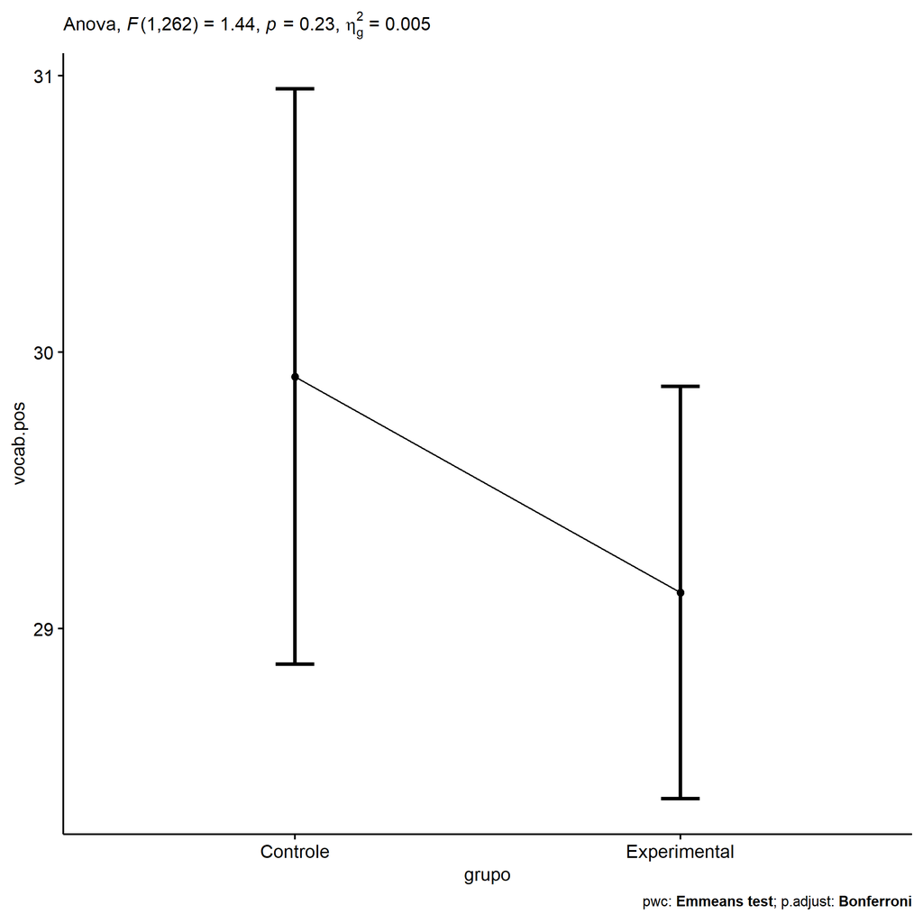

```r
if (!is.null(nrow(plots[["grupo"]]$data)))
  plots[["grupo"]] + ggplot2::scale_color_manual(values = color[["grupo"]])
```

```r
plots <- oneWayAncovaBoxPlots(
  wdat, "vocab.pos", "grupo", aov, pwc, covar = "vocab.pre",
  theme = "classic", color = color[["grupo"]],
  subtitle = which(aov$Effect == "grupo"))
```

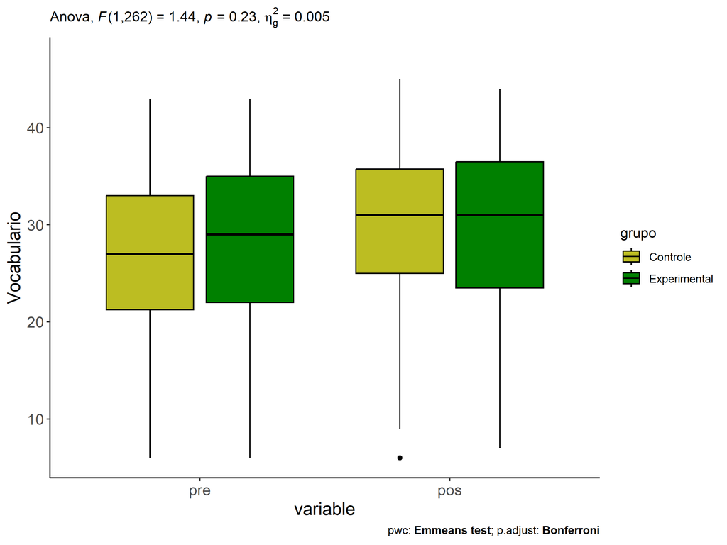

```r
if (length(unique(wdat[["grupo"]])) > 1)
  plots[["grupo"]] + ggplot2::ylab("Vocabulario") + ggplot2::scale_x_discrete(labels=c('pre', 'pos'))
```

```r
if (length(unique(wdat.long[["grupo"]])) > 1)
  plots <- oneWayAncovaBoxPlots(
    wdat.long, "vocab", "grupo", aov, pwc.long, pre.post = "time",
    theme = "classic", color = color$prepost)
```

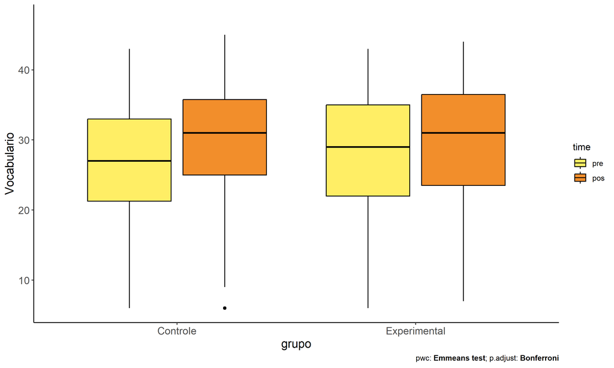

```r
if (length(unique(wdat.long[["grupo"]])) > 1)
  plots[["grupo"]] + ggplot2::ylab("Vocabulario")
```

### Checking linearity assumption

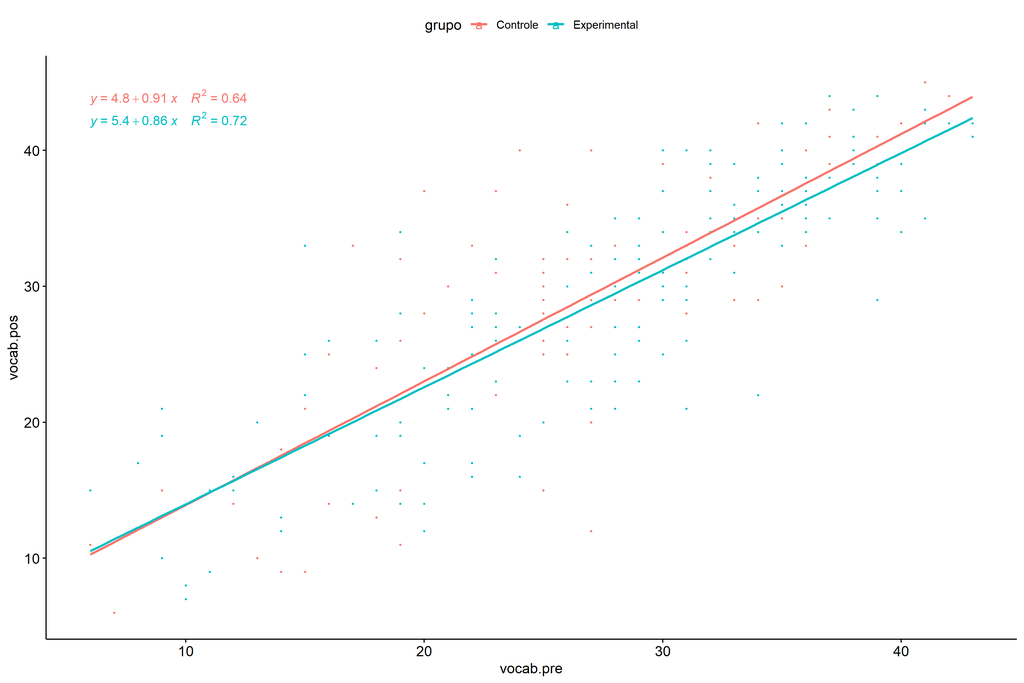

```r
ggscatter(wdat, x = "vocab.pre", y = "vocab.pos", size = 0.5,
          color = "grupo", add = "reg.line")+
  stat_regline_equation(
    aes(label =  paste(..eq.label.., ..rr.label.., sep = "~~~~"), color = grupo)
  )
```

### Checking normality and homogeneity

```r
res <- augment(lm(vocab.pos ~ vocab.pre + grupo, data = wdat))
```

```r
shapiro_test(res$.resid)
```

```
## # A tibble: 1 × 3
##   variable   statistic p.value
##   <chr>          <dbl>   <dbl>
## 1 res$.resid     0.992   0.167
```

```r
levene_test(res, .resid ~ grupo)
```

```
## # A tibble: 1 × 4
##     df1   df2 statistic     p
##   <int> <int>     <dbl> <dbl>
## 1     1   263      2.54 0.112
```

# ANCOVA and Pairwise for two factors **grupo:Sexo**

## Without remove non-normal data

```r
pdat = remove_group_data(dat[!is.na(dat[["grupo"]]) & !is.na(dat[["Sexo"]]),], "vocab.pos", c("grupo","Sexo"))

pdat.long <- rbind(pdat[,c("id","grupo","Sexo")], pdat[,c("id","grupo","Sexo")])
pdat.long[["time"]] <- c(rep("pre", nrow(pdat)), rep("pos", nrow(pdat)))
pdat.long[["time"]] <- factor(pdat.long[["time"]], c("pre","pos"))
pdat.long[["vocab"]] <- c(pdat[["vocab.pre"]], pdat[["vocab.pos"]])

aov = anova_test(pdat, vocab.pos ~ vocab.pre + grupo*Sexo)
laov[["grupo:Sexo"]] <- get_anova_table(aov)
```

```r
pwcs <- list()
pwcs[["Sexo"]] <- emmeans_test(
  group_by(pdat, grupo), vocab.pos ~ Sexo,
  covariate = vocab.pre, p.adjust.method = "bonferroni")
pwcs[["grupo"]] <- emmeans_test(
  group_by(pdat, Sexo), vocab.pos ~ grupo,
  covariate = vocab.pre, p.adjust.method = "bonferroni")

pwc <- plyr::rbind.fill(pwcs[["grupo"]], pwcs[["Sexo"]])
pwc <- pwc[,c("grupo","Sexo", colnames(pwc)[!colnames(pwc) %in% c("grupo","Sexo")])]
```

```r
pwc.long <- emmeans_test(dplyr::group_by_at(pdat.long, c("grupo","Sexo")),
                         vocab ~ time,
                         p.adjust.method = "bonferroni")
lpwc[["grupo:Sexo"]] <- plyr::rbind.fill(pwc, pwc.long)
```

```r
ds <- get.descriptives(pdat, "vocab.pos", c("grupo","Sexo"), covar = "vocab.pre")
ds <- merge(ds[ds$variable != "vocab.pre",],
            ds[ds$variable == "vocab.pre", !colnames(ds) %in% c("variable")],
            by = c("grupo","Sexo"), all.x = T, suffixes = c("", ".vocab.pre"))
ds <- merge(get_emmeans(pwcs[["grupo"]]), ds, by = c("grupo","Sexo"), suffixes = c(".emms", ""))
ds <- ds[,c("grupo","Sexo","n","mean.vocab.pre","se.vocab.pre","mean","se","emmean","se.emms")]

colnames(ds) <- c("grupo","Sexo", "N", paste0(c("M","SE")," (pre)"),
                  paste0(c("M","SE"), " (unadj)"), paste0(c("M", "SE"), " (adj)"))

lemms[["grupo:Sexo"]] <- ds
```

## Computing ANCOVA and PairWise After removing non-normal data (OK)

```r
wdat = pdat

res = residuals(lm(vocab.pos ~ vocab.pre + grupo*Sexo, data = wdat))
non.normal = getNonNormal(res, wdat$id, plimit = 0.05)

wdat = wdat[!wdat$id %in% non.normal,]

wdat.long <- rbind(wdat[,c("id","grupo","Sexo")], wdat[,c("id","grupo","Sexo")])
wdat.long[["time"]] <- c(rep("pre", nrow(wdat)), rep("pos", nrow(wdat)))
wdat.long[["time"]] <- factor(wdat.long[["time"]], c("pre","pos"))
wdat.long[["vocab"]] <- c(wdat[["vocab.pre"]], wdat[["vocab.pos"]])


ldat[["grupo:Sexo"]] = wdat

(non.normal)
```

```
##  [1] "P1003" "P2232" "P2207" "P2192" "P1056" "P1069" "P2245" "P996"  "P1006" "P3654" "P2176" "P2206" "P2251"
## [14] "P2219" "P1012"
```

```r
aov = anova_test(wdat, vocab.pos ~ vocab.pre + grupo*Sexo)
laov[["grupo:Sexo"]] <- merge(get_anova_table(aov), laov[["grupo:Sexo"]], by="Effect", suffixes = c("","'"))

(df = get_anova_table(aov))
```

```
## ANOVA Table (type II tests)
##
##       Effect DFn DFd       F        p p<.05      ges
## 1  vocab.pre   1 261 581.036 2.45e-68     * 6.90e-01
## 2      grupo   1 261   1.941 1.65e-01       7.00e-03
## 3       Sexo   1 261   4.173 4.20e-02     * 1.60e-02
## 4 grupo:Sexo   1 261   0.016 8.99e-01       6.19e-05
```

| Effect | DFn | DFd | F | p | p<.05 | ges |
| --- | --- | --- | --- | --- | --- | --- |
| vocab.pre | 1 | 261 | 581.036 | 0.000 | * | 0.690 |
| grupo | 1 | 261 | 1.941 | 0.165 |  | 0.007 |
| Sexo | 1 | 261 | 4.173 | 0.042 | * | 0.016 |
| grupo:Sexo | 1 | 261 | 0.016 | 0.899 |  | 0.000 |

```r
pwcs <- list()
pwcs[["Sexo"]] <- emmeans_test(
  group_by(wdat, grupo), vocab.pos ~ Sexo,
  covariate = vocab.pre, p.adjust.method = "bonferroni")
pwcs[["grupo"]] <- emmeans_test(
  group_by(wdat, Sexo), vocab.pos ~ grupo,
  covariate = vocab.pre, p.adjust.method = "bonferroni")

pwc <- plyr::rbind.fill(pwcs[["grupo"]], pwcs[["Sexo"]])
pwc <- pwc[,c("grupo","Sexo", colnames(pwc)[!colnames(pwc) %in% c("grupo","Sexo")])]
```

| grupo | Sexo | term | .y. | group1 | group2 | df | statistic | p | p.adj | p.adj.signif |
| --- | --- | --- | --- | --- | --- | --- | --- | --- | --- | --- |
|  | F | vocab.pre*grupo | vocab.pos | Controle | Experimental | 261 | 0.931 | 0.353 | 0.353 | ns |
|  | M | vocab.pre*grupo | vocab.pos | Controle | Experimental | 261 | 1.048 | 0.296 | 0.296 | ns |
| Controle |  | vocab.pre*Sexo | vocab.pos | F | M | 261 | 1.091 | 0.276 | 0.276 | ns |
| Experimental |  | vocab.pre*Sexo | vocab.pos | F | M | 261 | 1.740 | 0.083 | 0.083 | ns |

```r
pwc.long <- emmeans_test(dplyr::group_by_at(wdat.long, c("grupo","Sexo")),
                         vocab ~ time,
                         p.adjust.method = "bonferroni")
lpwc[["grupo:Sexo"]] <- merge(plyr::rbind.fill(pwc, pwc.long), lpwc[["grupo:Sexo"]], by=c("grupo","Sexo","term",".y.","group1","group2"), suffixes = c("","'"))
```

| grupo | Sexo | term | .y. | group1 | group2 | df | statistic | p | p.adj | p.adj.signif |
| --- | --- | --- | --- | --- | --- | --- | --- | --- | --- | --- |
| Controle | F | time | vocab | pre | pos | 524 | -1.621 | 0.106 | 0.106 | ns |
| Controle | M | time | vocab | pre | pos | 524 | -1.047 | 0.296 | 0.296 | ns |
| Experimental | F | time | vocab | pre | pos | 524 | -1.457 | 0.146 | 0.146 | ns |
| Experimental | M | time | vocab | pre | pos | 524 | -0.594 | 0.553 | 0.553 | ns |

```r
ds <- get.descriptives(wdat, "vocab.pos", c("grupo","Sexo"), covar = "vocab.pre")
ds <- merge(ds[ds$variable != "vocab.pre",],
            ds[ds$variable == "vocab.pre", !colnames(ds) %in% c("variable")],
            by = c("grupo","Sexo"), all.x = T, suffixes = c("", ".vocab.pre"))
ds <- merge(get_emmeans(pwcs[["grupo"]]), ds, by = c("grupo","Sexo"), suffixes = c(".emms", ""))
ds <- ds[,c("grupo","Sexo","n","mean.vocab.pre","se.vocab.pre","mean","se","emmean","se.emms")]

colnames(ds) <- c("grupo","Sexo", "N", paste0(c("M","SE")," (pre)"),
                  paste0(c("M","SE"), " (unadj)"), paste0(c("M", "SE"), " (adj)"))

lemms[["grupo:Sexo"]] <- merge(ds, lemms[["grupo:Sexo"]], by=c("grupo","Sexo"), suffixes = c("","'"))
```

| grupo | Sexo | N | M (pre) | SE (pre) | M (unadj) | SE (unadj) | M (adj) | SE (adj) |
| --- | --- | --- | --- | --- | --- | --- | --- | --- |
| Controle | F | 48 | 27.521 | 1.230 | 30.417 | 1.316 | 30.454 | 0.724 |
| Controle | M | 42 | 25.381 | 1.301 | 27.381 | 1.574 | 29.296 | 0.778 |
| Experimental | F | 93 | 29.097 | 0.930 | 30.968 | 0.895 | 29.623 | 0.523 |
| Experimental | M | 83 | 26.976 | 0.879 | 27.783 | 0.950 | 28.299 | 0.551 |

### Plots for ancova

```r
plots <- twoWayAncovaPlots(
  wdat, "vocab.pos", c("grupo","Sexo"), aov, pwcs, addParam = c("mean_se"),
  font.label.size=10, step.increase=0.05, p.label="p.adj",
  subtitle = which(aov$Effect == "grupo:Sexo"))
```

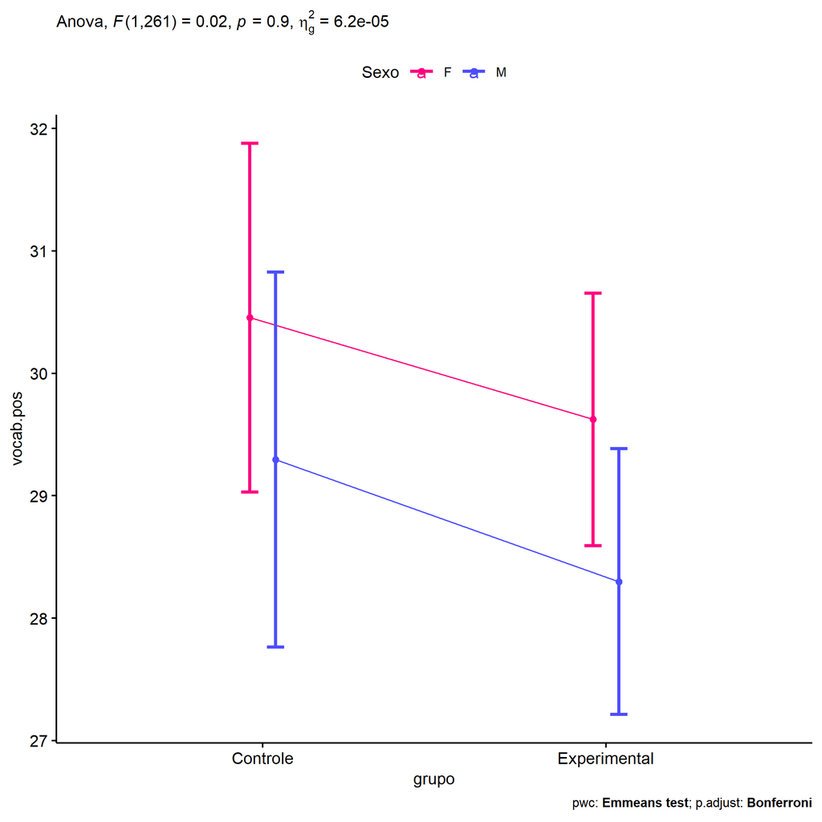

```r
if (!is.null(plots[["grupo"]]))
  plots[["grupo"]] + ggplot2::scale_color_manual(values = color[["Sexo"]])
```

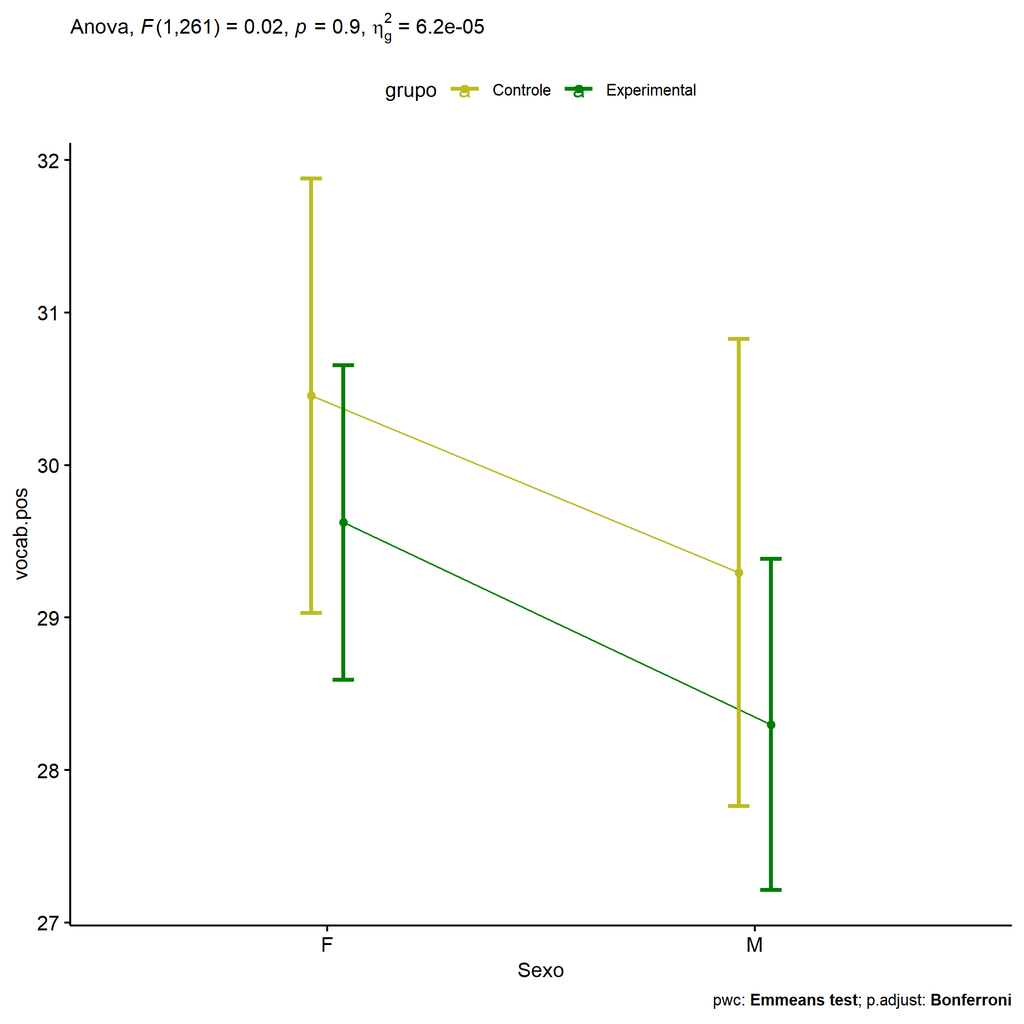

```r
if (!is.null(plots[["Sexo"]]))
  plots[["Sexo"]] + ggplot2::scale_color_manual(values = color[["grupo"]])
```

```r
plots <- twoWayAncovaBoxPlots(
  wdat, "vocab.pos", c("grupo","Sexo"), aov, pwcs, covar = "vocab.pre",
  theme = "classic", color = color[["grupo:Sexo"]],
  subtitle = which(aov$Effect == "grupo:Sexo"))
```

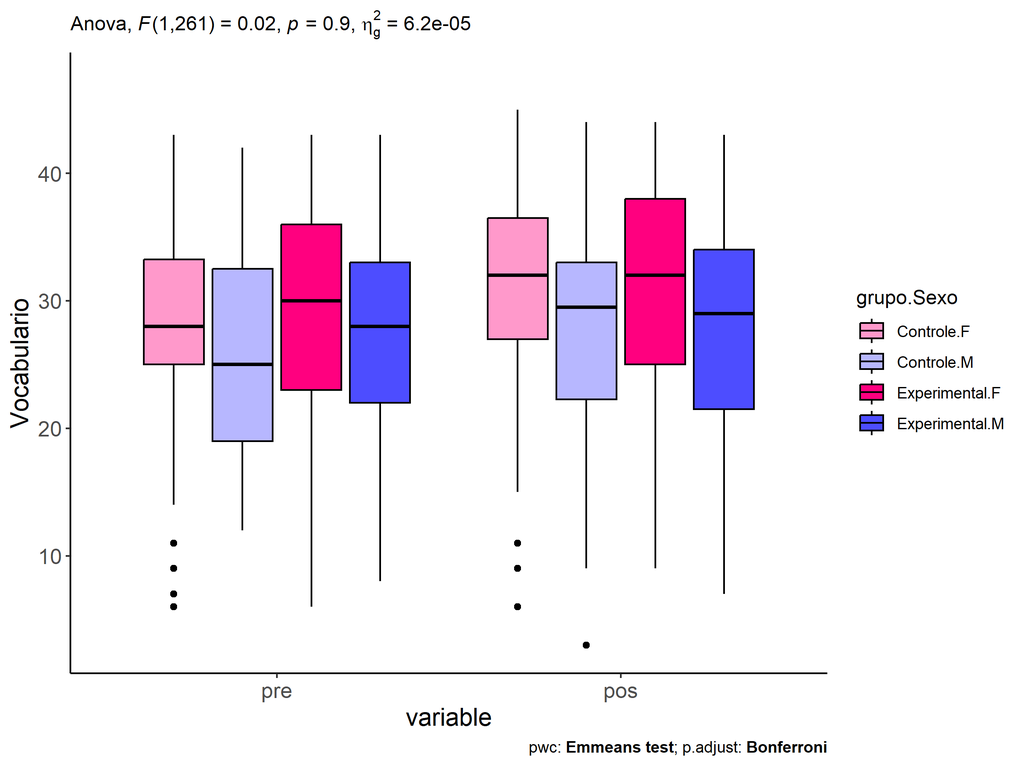

```r
plots[["grupo:Sexo"]] + ggplot2::ylab("Vocabulario") + ggplot2::scale_x_discrete(labels=c('pre', 'pos'))
```

```r
plots <- twoWayAncovaBoxPlots(
  wdat.long, "vocab", c("grupo","Sexo"), aov, pwc.long, pre.post = "time",
  theme = "classic", color = color$prepost)
```

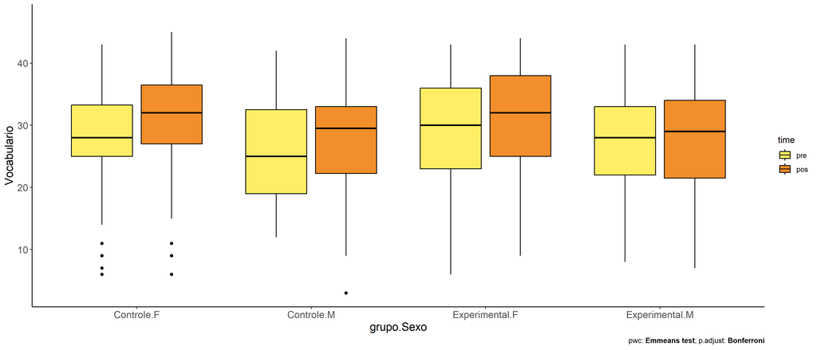

```r
plots[["grupo:Sexo"]] + ggplot2::ylab("Vocabulario")
```

### Checking linearity assumption

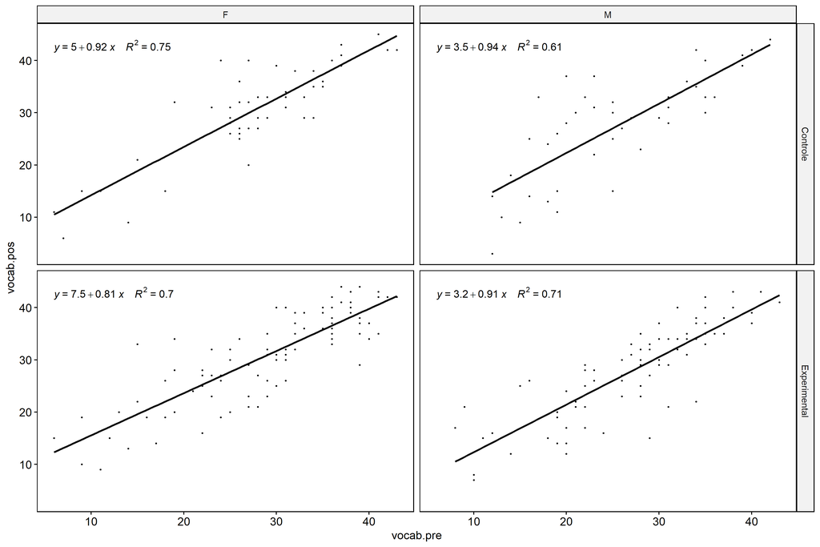

```r
ggscatter(wdat, x = "vocab.pre", y = "vocab.pos", size = 0.5,
          facet.by = c("grupo","Sexo"), add = "reg.line")+
  stat_regline_equation(
    aes(label =  paste(..eq.label.., ..rr.label.., sep = "~~~~"))
  )
```

### Checking normality and homogeneity

```r
res <- augment(lm(vocab.pos ~ vocab.pre + grupo*Sexo, data = wdat))
```

```r
shapiro_test(res$.resid)
```

```
## # A tibble: 1 × 3
##   variable   statistic p.value
##   <chr>          <dbl>   <dbl>
## 1 res$.resid     0.993   0.219
```

```r
levene_test(res, .resid ~ grupo*Sexo)
```

```
## # A tibble: 1 × 4
##     df1   df2 statistic      p
##   <int> <int>     <dbl>  <dbl>
## 1     3   262      2.62 0.0511
```

# ANCOVA and Pairwise for two factors **grupo:Zona**

## Without remove non-normal data

```r
pdat = remove_group_data(dat[!is.na(dat[["grupo"]]) & !is.na(dat[["Zona"]]),], "vocab.pos", c("grupo","Zona"))

pdat.long <- rbind(pdat[,c("id","grupo","Zona")], pdat[,c("id","grupo","Zona")])
pdat.long[["time"]] <- c(rep("pre", nrow(pdat)), rep("pos", nrow(pdat)))
pdat.long[["time"]] <- factor(pdat.long[["time"]], c("pre","pos"))
pdat.long[["vocab"]] <- c(pdat[["vocab.pre"]], pdat[["vocab.pos"]])

aov = anova_test(pdat, vocab.pos ~ vocab.pre + grupo*Zona)
laov[["grupo:Zona"]] <- get_anova_table(aov)
```

```r
pwcs <- list()
pwcs[["Zona"]] <- emmeans_test(
  group_by(pdat, grupo), vocab.pos ~ Zona,
  covariate = vocab.pre, p.adjust.method = "bonferroni")
pwcs[["grupo"]] <- emmeans_test(
  group_by(pdat, Zona), vocab.pos ~ grupo,
  covariate = vocab.pre, p.adjust.method = "bonferroni")

pwc <- plyr::rbind.fill(pwcs[["grupo"]], pwcs[["Zona"]])
pwc <- pwc[,c("grupo","Zona", colnames(pwc)[!colnames(pwc) %in% c("grupo","Zona")])]
```

```r
pwc.long <- emmeans_test(dplyr::group_by_at(pdat.long, c("grupo","Zona")),
                         vocab ~ time,
                         p.adjust.method = "bonferroni")
lpwc[["grupo:Zona"]] <- plyr::rbind.fill(pwc, pwc.long)
```

```r
ds <- get.descriptives(pdat, "vocab.pos", c("grupo","Zona"), covar = "vocab.pre")
ds <- merge(ds[ds$variable != "vocab.pre",],
            ds[ds$variable == "vocab.pre", !colnames(ds) %in% c("variable")],
            by = c("grupo","Zona"), all.x = T, suffixes = c("", ".vocab.pre"))
ds <- merge(get_emmeans(pwcs[["grupo"]]), ds, by = c("grupo","Zona"), suffixes = c(".emms", ""))
ds <- ds[,c("grupo","Zona","n","mean.vocab.pre","se.vocab.pre","mean","se","emmean","se.emms")]

colnames(ds) <- c("grupo","Zona", "N", paste0(c("M","SE")," (pre)"),
                  paste0(c("M","SE"), " (unadj)"), paste0(c("M", "SE"), " (adj)"))

lemms[["grupo:Zona"]] <- ds
```

## Computing ANCOVA and PairWise After removing non-normal data (OK)

```r
wdat = pdat

res = residuals(lm(vocab.pos ~ vocab.pre + grupo*Zona, data = wdat))
non.normal = getNonNormal(res, wdat$id, plimit = 0.05)

wdat = wdat[!wdat$id %in% non.normal,]

wdat.long <- rbind(wdat[,c("id","grupo","Zona")], wdat[,c("id","grupo","Zona")])
wdat.long[["time"]] <- c(rep("pre", nrow(wdat)), rep("pos", nrow(wdat)))
wdat.long[["time"]] <- factor(wdat.long[["time"]], c("pre","pos"))
wdat.long[["vocab"]] <- c(wdat[["vocab.pre"]], wdat[["vocab.pos"]])


ldat[["grupo:Zona"]] = wdat

(non.normal)
```

```
## [1] "P2207" "P3654" "P1056"
```

```r
aov = anova_test(wdat, vocab.pos ~ vocab.pre + grupo*Zona)
laov[["grupo:Zona"]] <- merge(get_anova_table(aov), laov[["grupo:Zona"]], by="Effect", suffixes = c("","'"))

(df = get_anova_table(aov))
```

```
## ANOVA Table (type II tests)
##
##       Effect DFn DFd       F        p p<.05   ges
## 1  vocab.pre   1 137 271.554 2.60e-34     * 0.665
## 2      grupo   1 137   0.787 3.77e-01       0.006
## 3       Zona   1 137   2.222 1.38e-01       0.016
## 4 grupo:Zona   1 137   1.053 3.07e-01       0.008
```

| Effect | DFn | DFd | F | p | p<.05 | ges |
| --- | --- | --- | --- | --- | --- | --- |
| vocab.pre | 1 | 137 | 271.554 | 0.000 | * | 0.665 |
| grupo | 1 | 137 | 0.787 | 0.377 |  | 0.006 |
| Zona | 1 | 137 | 2.222 | 0.138 |  | 0.016 |
| grupo:Zona | 1 | 137 | 1.053 | 0.307 |  | 0.008 |

```r
pwcs <- list()
pwcs[["Zona"]] <- emmeans_test(
  group_by(wdat, grupo), vocab.pos ~ Zona,
  covariate = vocab.pre, p.adjust.method = "bonferroni")
pwcs[["grupo"]] <- emmeans_test(
  group_by(wdat, Zona), vocab.pos ~ grupo,
  covariate = vocab.pre, p.adjust.method = "bonferroni")

pwc <- plyr::rbind.fill(pwcs[["grupo"]], pwcs[["Zona"]])
pwc <- pwc[,c("grupo","Zona", colnames(pwc)[!colnames(pwc) %in% c("grupo","Zona")])]
```

| grupo | Zona | term | .y. | group1 | group2 | df | statistic | p | p.adj | p.adj.signif |
| --- | --- | --- | --- | --- | --- | --- | --- | --- | --- | --- |
|  | Rural | vocab.pre*grupo | vocab.pos | Controle | Experimental | 137 | 0.116 | 0.907 | 0.907 | ns |
|  | Urbana | vocab.pre*grupo | vocab.pos | Controle | Experimental | 137 | 1.352 | 0.179 | 0.179 | ns |
| Controle |  | vocab.pre*Zona | vocab.pos | Rural | Urbana | 137 | -1.723 | 0.087 | 0.087 | ns |
| Experimental |  | vocab.pre*Zona | vocab.pos | Rural | Urbana | 137 | -0.554 | 0.580 | 0.580 | ns |

```r
pwc.long <- emmeans_test(dplyr::group_by_at(wdat.long, c("grupo","Zona")),
                         vocab ~ time,
                         p.adjust.method = "bonferroni")
lpwc[["grupo:Zona"]] <- merge(plyr::rbind.fill(pwc, pwc.long), lpwc[["grupo:Zona"]], by=c("grupo","Zona","term",".y.","group1","group2"), suffixes = c("","'"))
```

| grupo | Zona | term | .y. | group1 | group2 | df | statistic | p | p.adj | p.adj.signif |
| --- | --- | --- | --- | --- | --- | --- | --- | --- | --- | --- |
| Controle | Rural | time | vocab | pre | pos | 276 | -0.847 | 0.398 | 0.398 | ns |
| Controle | Urbana | time | vocab | pre | pos | 276 | -1.485 | 0.139 | 0.139 | ns |
| Experimental | Rural | time | vocab | pre | pos | 276 | -0.902 | 0.368 | 0.368 | ns |
| Experimental | Urbana | time | vocab | pre | pos | 276 | -0.926 | 0.355 | 0.355 | ns |

```r
ds <- get.descriptives(wdat, "vocab.pos", c("grupo","Zona"), covar = "vocab.pre")
ds <- merge(ds[ds$variable != "vocab.pre",],
            ds[ds$variable == "vocab.pre", !colnames(ds) %in% c("variable")],
            by = c("grupo","Zona"), all.x = T, suffixes = c("", ".vocab.pre"))
ds <- merge(get_emmeans(pwcs[["grupo"]]), ds, by = c("grupo","Zona"), suffixes = c(".emms", ""))
ds <- ds[,c("grupo","Zona","n","mean.vocab.pre","se.vocab.pre","mean","se","emmean","se.emms")]

colnames(ds) <- c("grupo","Zona", "N", paste0(c("M","SE")," (pre)"),
                  paste0(c("M","SE"), " (unadj)"), paste0(c("M", "SE"), " (adj)"))

lemms[["grupo:Zona"]] <- merge(ds, lemms[["grupo:Zona"]], by=c("grupo","Zona"), suffixes = c("","'"))
```

| grupo | Zona | N | M (pre) | SE (pre) | M (unadj) | SE (unadj) | M (adj) | SE (adj) |
| --- | --- | --- | --- | --- | --- | --- | --- | --- |
| Controle | Rural | 37 | 26.703 | 1.405 | 28.405 | 1.631 | 29.157 | 0.865 |
| Controle | Urbana | 18 | 26.944 | 1.800 | 31.222 | 1.900 | 31.757 | 1.238 |
| Experimental | Rural | 54 | 27.389 | 1.137 | 28.889 | 1.212 | 29.026 | 0.715 |
| Experimental | Urbana | 33 | 29.061 | 1.388 | 31.030 | 1.512 | 29.671 | 0.918 |

### Plots for ancova

```r
plots <- twoWayAncovaPlots(
  wdat, "vocab.pos", c("grupo","Zona"), aov, pwcs, addParam = c("mean_se"),
  font.label.size=10, step.increase=0.05, p.label="p.adj",
  subtitle = which(aov$Effect == "grupo:Zona"))
```

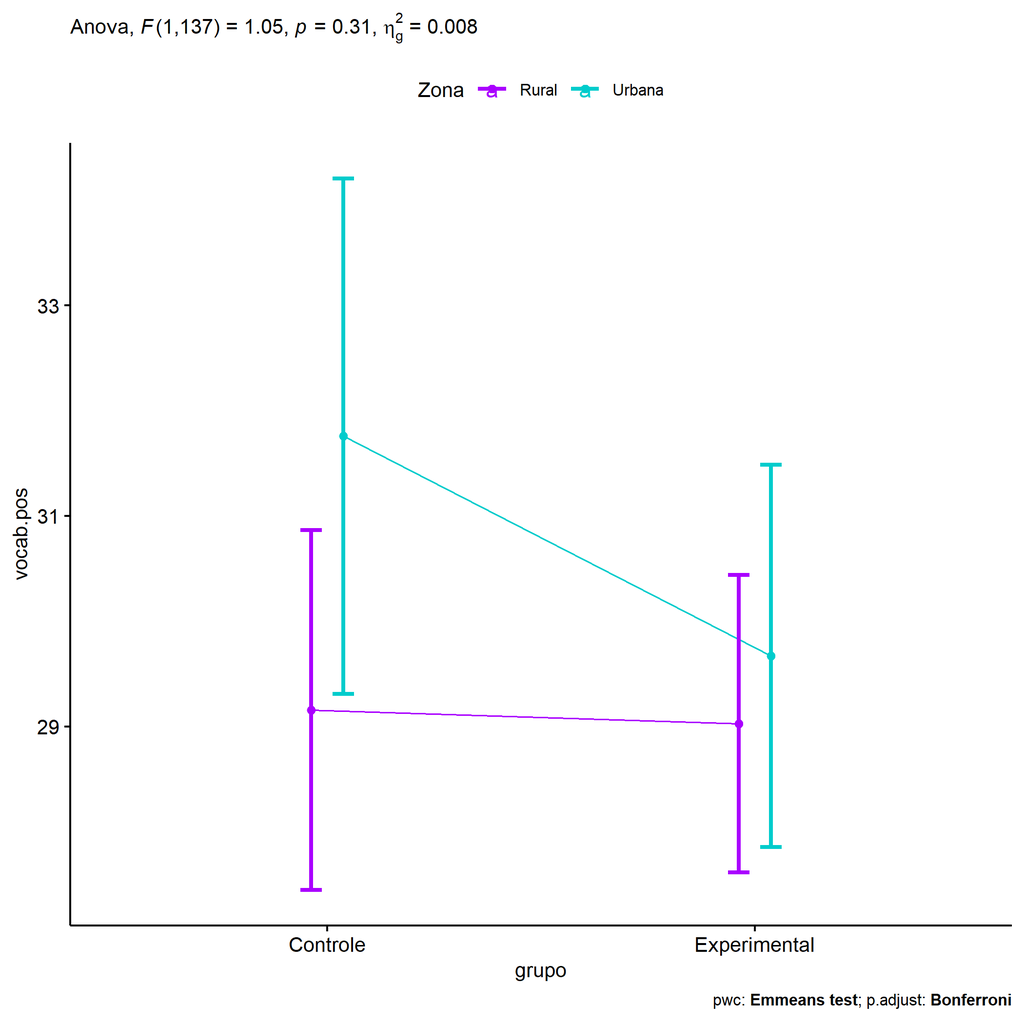

```r
if (!is.null(plots[["grupo"]]))
  plots[["grupo"]] + ggplot2::scale_color_manual(values = color[["Zona"]])
```

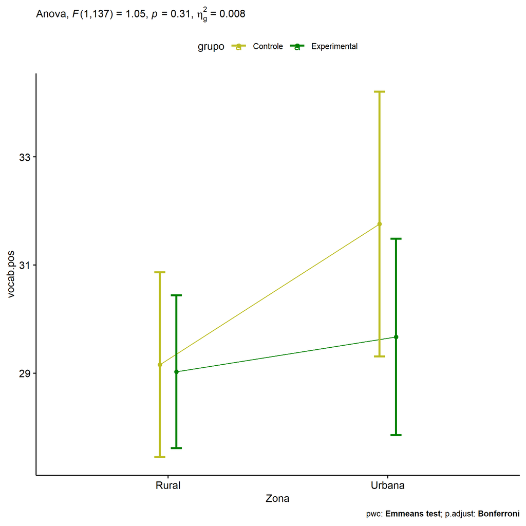

```r
if (!is.null(plots[["Zona"]]))
  plots[["Zona"]] + ggplot2::scale_color_manual(values = color[["grupo"]])
```

```r
plots <- twoWayAncovaBoxPlots(
  wdat, "vocab.pos", c("grupo","Zona"), aov, pwcs, covar = "vocab.pre",
  theme = "classic", color = color[["grupo:Zona"]],
  subtitle = which(aov$Effect == "grupo:Zona"))
```

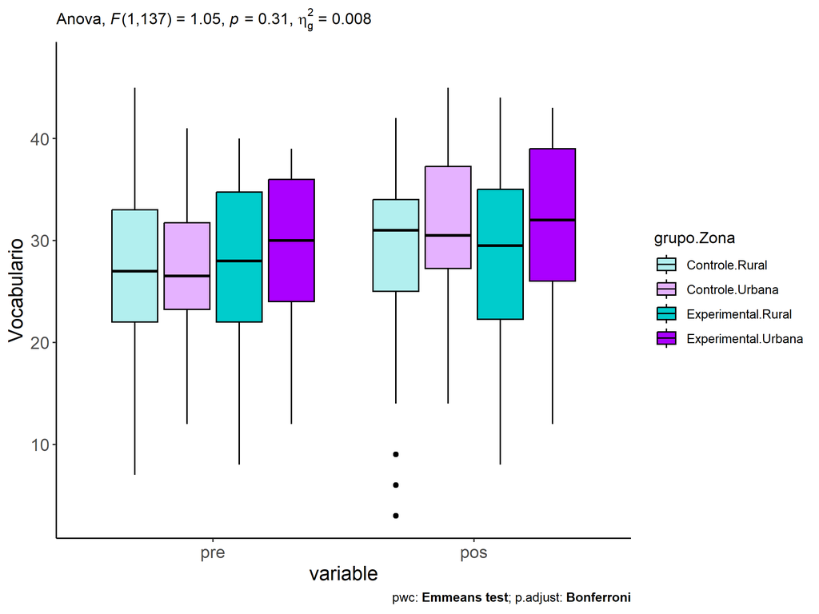

```r
plots[["grupo:Zona"]] + ggplot2::ylab("Vocabulario") + ggplot2::scale_x_discrete(labels=c('pre', 'pos'))
```

```r
plots <- twoWayAncovaBoxPlots(
  wdat.long, "vocab", c("grupo","Zona"), aov, pwc.long, pre.post = "time",
  theme = "classic", color = color$prepost)
```

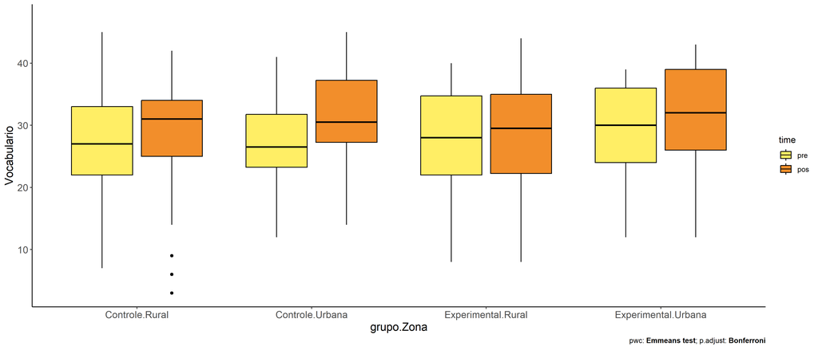

```r
plots[["grupo:Zona"]] + ggplot2::ylab("Vocabulario")
```

### Checking linearity assumption

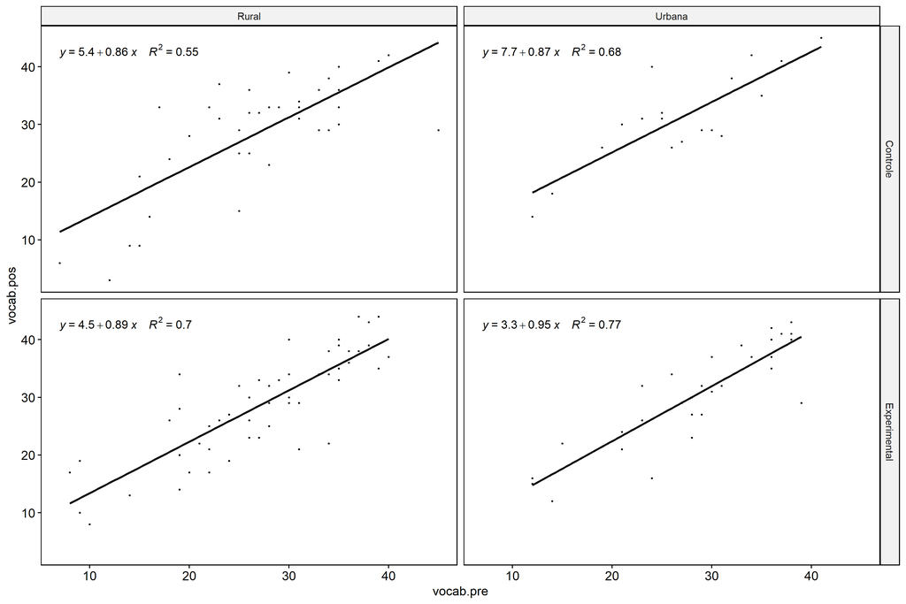

```r
ggscatter(wdat, x = "vocab.pre", y = "vocab.pos", size = 0.5,
          facet.by = c("grupo","Zona"), add = "reg.line")+
  stat_regline_equation(
    aes(label =  paste(..eq.label.., ..rr.label.., sep = "~~~~"))
  )
```

### Checking normality and homogeneity

```r
res <- augment(lm(vocab.pos ~ vocab.pre + grupo*Zona, data = wdat))
```

```r
shapiro_test(res$.resid)
```

```
## # A tibble: 1 × 3
##   variable   statistic p.value
##   <chr>          <dbl>   <dbl>
## 1 res$.resid     0.987   0.209
```

```r
levene_test(res, .resid ~ grupo*Zona)
```

```
## # A tibble: 1 × 4
##     df1   df2 statistic      p
##   <int> <int>     <dbl>  <dbl>
## 1     3   138      2.33 0.0774
```

# ANCOVA and Pairwise for two factors **grupo:Cor.Raca**

## Without remove non-normal data

```r
pdat = remove_group_data(dat[!is.na(dat[["grupo"]]) & !is.na(dat[["Cor.Raca"]]),], "vocab.pos", c("grupo","Cor.Raca"))
pdat.long <- rbind(pdat[,c("id","grupo","Cor.Raca")], pdat[,c("id","grupo","Cor.Raca")])
pdat.long[["time"]] <- c(rep("pre", nrow(pdat)), rep("pos", nrow(pdat)))
pdat.long[["time"]] <- factor(pdat.long[["time"]], c("pre","pos"))
pdat.long[["vocab"]] <- c(pdat[["vocab.pre"]], pdat[["vocab.pos"]])

aov = anova_test(pdat, vocab.pos ~ vocab.pre + grupo*Cor.Raca)
laov[["grupo:Cor.Raca"]] <- get_anova_table(aov)
```

```r
pwcs <- list()
pwcs[["Cor.Raca"]] <- emmeans_test(
  group_by(pdat, grupo), vocab.pos ~ Cor.Raca,
  covariate = vocab.pre, p.adjust.method = "bonferroni")
pwcs[["grupo"]] <- emmeans_test(
  group_by(pdat, Cor.Raca), vocab.pos ~ grupo,
  covariate = vocab.pre, p.adjust.method = "bonferroni")

pwc <- plyr::rbind.fill(pwcs[["grupo"]], pwcs[["Cor.Raca"]])
pwc <- pwc[,c("grupo","Cor.Raca", colnames(pwc)[!colnames(pwc) %in% c("grupo","Cor.Raca")])]
```

```r
pwc.long <- emmeans_test(dplyr::group_by_at(pdat.long, c("grupo","Cor.Raca")),
                         vocab ~ time,
                         p.adjust.method = "bonferroni")
lpwc[["grupo:Cor.Raca"]] <- plyr::rbind.fill(pwc, pwc.long)
```

```r
ds <- get.descriptives(pdat, "vocab.pos", c("grupo","Cor.Raca"), covar = "vocab.pre")
ds <- merge(ds[ds$variable != "vocab.pre",],
            ds[ds$variable == "vocab.pre", !colnames(ds) %in% c("variable")],
            by = c("grupo","Cor.Raca"), all.x = T, suffixes = c("", ".vocab.pre"))
ds <- merge(get_emmeans(pwcs[["grupo"]]), ds, by = c("grupo","Cor.Raca"), suffixes = c(".emms", ""))
ds <- ds[,c("grupo","Cor.Raca","n","mean.vocab.pre","se.vocab.pre","mean","se","emmean","se.emms")]

colnames(ds) <- c("grupo","Cor.Raca", "N", paste0(c("M","SE")," (pre)"),
                  paste0(c("M","SE"), " (unadj)"), paste0(c("M", "SE"), " (adj)"))

lemms[["grupo:Cor.Raca"]] <- ds
```

## Computing ANCOVA and PairWise After removing non-normal data (OK)

```r
wdat = pdat

res = residuals(lm(vocab.pos ~ vocab.pre + grupo*Cor.Raca, data = wdat))
non.normal = getNonNormal(res, wdat$id, plimit = 0.05)

wdat = wdat[!wdat$id %in% non.normal,]

wdat.long <- rbind(wdat[,c("id","grupo","Cor.Raca")], wdat[,c("id","grupo","Cor.Raca")])
wdat.long[["time"]] <- c(rep("pre", nrow(wdat)), rep("pos", nrow(wdat)))
wdat.long[["time"]] <- factor(wdat.long[["time"]], c("pre","pos"))
wdat.long[["vocab"]] <- c(wdat[["vocab.pre"]], wdat[["vocab.pos"]])


ldat[["grupo:Cor.Raca"]] = wdat

(non.normal)
```

```
## [1] "P1003" "P1069" "P996"  "P1056"
```

```r
aov = anova_test(wdat, vocab.pos ~ vocab.pre + grupo*Cor.Raca)
laov[["grupo:Cor.Raca"]] <- merge(get_anova_table(aov), laov[["grupo:Cor.Raca"]], by="Effect", suffixes = c("","'"))

(df = get_anova_table(aov))
```

```
## ANOVA Table (type II tests)
##
##           Effect DFn DFd       F        p p<.05     ges
## 1      vocab.pre   1 102 130.866 5.43e-20     * 0.56200
## 2          grupo   1 102   0.003 9.56e-01       0.00003
## 3       Cor.Raca   1 102   1.395 2.40e-01       0.01300
## 4 grupo:Cor.Raca   0 102      NA       NA  <NA>      NA
```

| Effect | DFn | DFd | F | p | p<.05 | ges |
| --- | --- | --- | --- | --- | --- | --- |
| vocab.pre | 1 | 102 | 130.866 | 0.000 | * | 0.562 |
| grupo | 1 | 102 | 0.003 | 0.956 |  | 0.000 |
| Cor.Raca | 1 | 102 | 1.395 | 0.240 |  | 0.013 |
| grupo:Cor.Raca | 0 | 102 |  |  |  |  |

```r
pwcs <- list()
pwcs[["Cor.Raca"]] <- emmeans_test(
  group_by(wdat, grupo), vocab.pos ~ Cor.Raca,
  covariate = vocab.pre, p.adjust.method = "bonferroni")
pwcs[["grupo"]] <- emmeans_test(
  group_by(wdat, Cor.Raca), vocab.pos ~ grupo,
  covariate = vocab.pre, p.adjust.method = "bonferroni")

pwc <- plyr::rbind.fill(pwcs[["grupo"]], pwcs[["Cor.Raca"]])
pwc <- pwc[,c("grupo","Cor.Raca", colnames(pwc)[!colnames(pwc) %in% c("grupo","Cor.Raca")])]
```

| grupo | Cor.Raca | term | .y. | group1 | group2 | df | statistic | p | p.adj | p.adj.signif |
| --- | --- | --- | --- | --- | --- | --- | --- | --- | --- | --- |
|  | Branca | vocab.pre*grupo | vocab.pos | Controle | Experimental |  |  |  |  |  |
|  | Parda | vocab.pre*grupo | vocab.pos | Controle | Experimental | 102 | 0.055 | 0.956 | 0.956 | ns |
| Controle |  | vocab.pre*Cor.Raca | vocab.pos | Branca | Parda |  |  |  |  |  |
| Experimental |  | vocab.pre*Cor.Raca | vocab.pos | Branca | Parda | 102 | -1.181 | 0.240 | 0.240 | ns |

```r
pwc.long <- emmeans_test(dplyr::group_by_at(wdat.long, c("grupo","Cor.Raca")),
                         vocab ~ time,
                         p.adjust.method = "bonferroni")
lpwc[["grupo:Cor.Raca"]] <- merge(plyr::rbind.fill(pwc, pwc.long), lpwc[["grupo:Cor.Raca"]], by=c("grupo","Cor.Raca","term",".y.","group1","group2"), suffixes = c("","'"))
```

| grupo | Cor.Raca | term | .y. | group1 | group2 | df | statistic | p | p.adj | p.adj.signif |
| --- | --- | --- | --- | --- | --- | --- | --- | --- | --- | --- |
| Controle | Branca | time | vocab | pre | pos |  |  |  |  |  |
| Controle | Parda | time | vocab | pre | pos | 206 | -0.953 | 0.342 | 0.342 | ns |
| Experimental | Branca | time | vocab | pre | pos | 206 | 0.177 | 0.860 | 0.860 | ns |
| Experimental | Parda | time | vocab | pre | pos | 206 | -1.145 | 0.254 | 0.254 | ns |

```r
ds <- get.descriptives(wdat, "vocab.pos", c("grupo","Cor.Raca"), covar = "vocab.pre")
ds <- merge(ds[ds$variable != "vocab.pre",],
            ds[ds$variable == "vocab.pre", !colnames(ds) %in% c("variable")],
            by = c("grupo","Cor.Raca"), all.x = T, suffixes = c("", ".vocab.pre"))
ds <- merge(get_emmeans(pwcs[["grupo"]]), ds, by = c("grupo","Cor.Raca"), suffixes = c(".emms", ""))
ds <- ds[,c("grupo","Cor.Raca","n","mean.vocab.pre","se.vocab.pre","mean","se","emmean","se.emms")]

colnames(ds) <- c("grupo","Cor.Raca", "N", paste0(c("M","SE")," (pre)"),
                  paste0(c("M","SE"), " (unadj)"), paste0(c("M", "SE"), " (adj)"))

lemms[["grupo:Cor.Raca"]] <- merge(ds, lemms[["grupo:Cor.Raca"]], by=c("grupo","Cor.Raca"), suffixes = c("","'"))
```

| grupo | Cor.Raca | N | M (pre) | SE (pre) | M (unadj) | SE (unadj) | M (adj) | SE (adj) |
| --- | --- | --- | --- | --- | --- | --- | --- | --- |
| Controle | Parda | 34 | 26.912 | 1.389 | 29.029 | 1.731 | 29.493 | 1.097 |
| Experimental | Branca | 19 | 30.000 | 1.453 | 29.474 | 2.015 | 27.380 | 1.478 |
| Experimental | Parda | 53 | 26.925 | 1.334 | 28.962 | 1.314 | 29.415 | 0.879 |